# n8_2_inventory_management

## Brief introduction to SimPy

SimPy is a process-based discrete-event simulation framework based on Python.

The behavior of active components (like vehicles, customers or messages) is modeled with processes. All processes live in an environment. They interact with the environment and with each other via events.

First, check if simpy is installed, otherwise use the following line for a quick install:

```python
!pip install simpy
```

```python
import simpy
import matplotlib.pyplot as plt
```

### Car parking example

We will create a car process that has two possible actions: drive and park.

Processes are described by Python **generators**. During their lifetime, they create events and **yield** them in order to wait for them to be triggered.

An important event type is the **timeout**. Events of this type are triggered after a certain amount of (simulated) time has passed. They allow a process to sleep (or hold its state) for the given time.

In our car parking example, the two actions (drive and park), are defined as events with different timeout durations.

```python
 def car(env):
    while True:
        print('Start parking at %d' % env.now)
        parking_duration = 5
        yield env.timeout(parking_duration)

        print('Start driving at %d' % env.now)
        trip_duration = 2
        yield env.timeout(trip_duration)
```

Once we have created the car process, we must define a simuation **environment** and run the process for a certain amount of time.

Events within the process will be yielded consecutively until time runs out.

```python
env = simpy.Environment()
env.process(car(env))
env.run(until=30)
```

```
Start parking at 0
Start driving at 5
Start parking at 7
Start driving at 12
Start parking at 14
Start driving at 19
Start parking at 21
Start driving at 26
Start parking at 28
```

Different processes can interact within the same environment, giving rise to complex simulation models.

We encourage you to look for additional information regarding SimPy and it's different uses in the official documentation:

https://simpy.readthedocs.io/en/latest/contents.html

Now, we will use a model based on SimPy to approach an Inventory Management problem.

## Problem Statement

A company that sells a single product would like to decide how many items it should have in inventory for each of the next n months. The times between demands are IID exponential random variables with a mean of 0.1 month. The sizes of the demands, D, are IID random variables (independent of when the demands occur), with

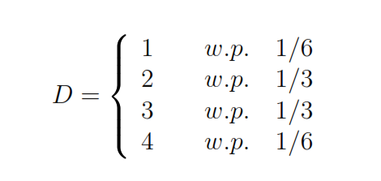

At the beginning of each month, the company reviews the inventory level and decides how many items to order from its supplier. If the company orders $Q$ items, it incurs a cost of $K + iZ$, where $K= \unicode{163} 32$ is the setup cost and $i=\unicode{163}3$ is the incremental cost per item ordered (if $Q=0$, no cost is incurred). When an order is placed, the time required for ir to arrive (called the lag or lead time) is a random variable that is distributed uniformly between 0.5 and 1 month.

The company uses a stationary (s, S) policy to decide how much to order i.e.,

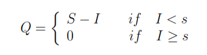

where I is the inventory level at the beginning of the month. When a demand occurs, it is satisfied immediately if the inventory level is ar least as large. If the demand exceeds the inventory, the difference is backlogged and satisfied in future deliveries.

In addition to the ordering costs, we will consider two other costs:

- Holding cost $h$: this includes such costs as warehouse rental, insurance, taxes and maintenance. We will assume $\unicode{163} 1$ per item held in inventory per month.
- Shortage cost $\pi$: this accounts for the cost of extra record keeping when a backlog exists as well as loss of customers' goodwill. We will assume $\unicode{163} 5$ per item in backlog per month.

We want to compare different values for the policy (s,S) in a simulated environment, for a period of 120 months. The values for (s,S) can be found below. Assume the initial inventory is set to 60.

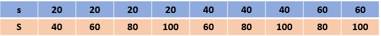

### SimPy Model

The complete model for this problem is in the file model.py. As you can see, it is composed of three SimPy processes that interact with each other within the same environment:

- check_inventory: Checks inventory at regular interval and places order if needed
- place_order: Places order and updates inventory level when order has been received
- demand: Generates demand at random intervals and updates inventory level

In addition, the function update_costs calculates shortage and holding costs before each change in inventory.

```python
import numpy as np
import model
import matplotlib.pyplot as plt
```

The function will return a dictionary containing user input parameters (reorder point, order size) and the model output (average monthly total inventory cost, ordering cost, shortage cost and holding cost).

Let's run a few iterations and have a look at their output. Note that the model contains random variables (delivery delay and demand size and intervals), therefore different results will be obtained by independent runs.

s = reorder_point

S = reorder_point + order_size

```python
# perform a single run of the inventory simulation model
results, history = model.run(length = 120., reorder_point = 20, order_size = 20)
```

```python
results
```

```
{'reorder_point': 20,
 'order_size': 20,
 'total_cost': 124.3,
 'ordering_cost': 98.9,
 'holding_cost': 9.5,
 'shortage_cost': 15.8}
```

we can look at the inventory history in a bar graph. The negative values correspond to the demand backlog.

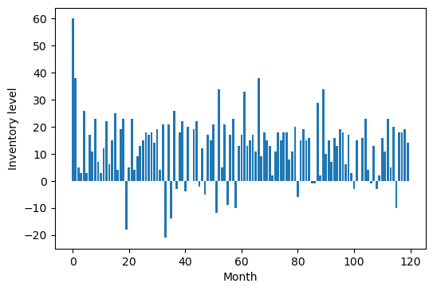

```python
fig, ax = plt.subplots(dpi=100)
plt.bar(range(120),history)
plt.xlabel('Month')
plt.ylabel('Inventory level')
```

### Building a confidence interval for total inventory cost

Unless the simulation model is purely deterministic (i.e. there is no randomness in the model), it will be required to conduct a statistical analysis of the simulation output.

Running a single iteration of the simulation and reporting the performance measures is not a recommended approach. As we saw above, independent replications of a simulation will yield different output, which can result in making poor decisions.

By doing several independent replications of each configurations allows to measure the spread of results and build a confidence interval for the average performance of the system.

```python
import pandas as pd

length = 120.
num_replications = 15
reorder_point = 30
order_size = 60

df = pd.DataFrame(model.run_experiments(length, [reorder_point], [order_size], num_replications))
df
```

|  | reorder_point | order_size | total_cost | ordering_cost | holding_cost | shortage_cost |
| --- | --- | --- | --- | --- | --- | --- |
| 0 | 30 | 60 | 123.0 | 84.0 | 36.0 | 3.1 |
| 1 | 30 | 60 | 125.7 | 86.6 | 35.1 | 4.0 |
| 2 | 30 | 60 | 120.7 | 81.2 | 37.3 | 2.2 |
| 3 | 30 | 60 | 123.1 | 84.7 | 34.4 | 4.0 |
| 4 | 30 | 60 | 130.7 | 90.7 | 34.4 | 5.6 |
| 5 | 30 | 60 | 125.1 | 85.0 | 36.8 | 3.3 |
| 6 | 30 | 60 | 119.3 | 78.2 | 36.6 | 4.5 |
| 7 | 30 | 60 | 122.4 | 83.1 | 37.6 | 1.7 |
| 8 | 30 | 60 | 122.5 | 83.7 | 34.6 | 4.2 |
| 9 | 30 | 60 | 123.5 | 84.1 | 36.4 | 3.0 |
| 10 | 30 | 60 | 124.3 | 84.4 | 36.0 | 3.9 |
| 11 | 30 | 60 | 123.2 | 85.0 | 34.4 | 3.7 |
| 12 | 30 | 60 | 127.6 | 88.7 | 35.0 | 3.8 |
| 13 | 30 | 60 | 124.7 | 86.6 | 34.5 | 3.7 |
| 14 | 30 | 60 | 126.3 | 86.4 | 35.4 | 4.4 |

We then need to compute our sample mean and sample standard deviation of the total cost output.

Because our sample size is small (less than 30 observations is often used as a rule of thumb), we'll use a t-statistics (as opposed to a z-statistics) to build our confidence interval.

```python
from scipy import stats

# compute sample mean and standard deviation
mean = df['total_cost'].mean()
std = df['total_cost'].std()

# compute t-statistics for a 90% confidence interval
alpha = 1-.9
tstat = stats.t.ppf(1-alpha/2, num_replications - 1)

# compute confidence interval
error_margin = tstat * std / np.sqrt(num_replications)
lbound = mean - error_margin
ubound = mean + error_margin

print("90 percent confidence interval for monthly inventory cost: [%.1f, %.1f]" % (lbound, ubound))
```

```
90 percent confidence interval for monthly inventory cost: [122.9, 125.4]
```

It is a good practice to build confidence intervals whenever performance indicators need to be assessed.

They add valuable information to the average. If system A yields a performance of (100 +- 1) and B yields (100 +- 15), while on average the performance is the same, B is much riskier than A.

Confidence intervals are also interpretable without deep statistical knowledge, which makes it convenient to communicate with simulation stakeholders.

### Comparing alternative configurations

We can now compare the different configurations for the policy (s,S) given in the problem statement.

For each configuration, we will run 30 independent runs and compare the average of the total costs.

```python
s = [20, 20, 20, 20, 40, 40, 40, 60, 60]
S = [40, 60, 80, 100, 60, 80, 100, 80 ,100]

num_rep = 30

total_cost_runs = []
total_cost = []
ordering_cost_runs = []
ordering_cost = []
holding_cost_runs = []
holding_cost = []
shortage_cost_runs = []
shortage_cost = []


for j,k in zip(s,S):
    for i in range(num_rep):

        res, _ = model.run(length = 120., reorder_point = j, order_size = k-j)
        total_cost_runs.append(res['total_cost'])
        ordering_cost_runs.append(res['ordering_cost'])
        holding_cost_runs.append(res['holding_cost'])
        shortage_cost_runs.append(res['shortage_cost'])

    # compute the average for each sample
    total_cost.append(np.mean(total_cost_runs))
    ordering_cost.append(np.mean(ordering_cost_runs))
    holding_cost.append(np.mean(holding_cost_runs))
    shortage_cost.append(np.mean(shortage_cost_runs))

df = pd.DataFrame([zip(s,S), total_cost, ordering_cost, holding_cost, shortage_cost])
df = df.T
df.columns = ['(s,S)','Total Cost','Ordering Cost','Holding Cost','Shortage Cost']
```

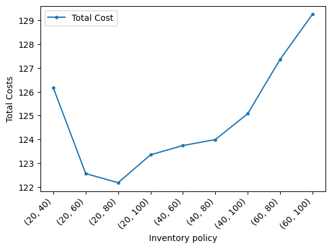

```python
fig, ax = plt.subplots(dpi=100)
ax.plot(df['Total Cost'], label='Total Cost', marker='.')
plt.xticks(range(len(s)), df['(s,S)'])
plt.xticks(rotation=45,ha='right')
plt.xlabel('Inventory policy')
plt.ylabel('Total Costs')
plt.legend()
plt.show()
```

We can also look at how the different costs vary for the different configurations.

We notice that increasing S from 40 to 100, increases the holding costs steadily, while reducing the shortage cost.

The effect of the increase in S on the ordering cost is to reduce it, since ordering up to larger values of S implies that these larger orders will be placed less frequently, thereby avoiding the fixed ordering cost more often.

Similarly, fixing S at, say, 100, and increasing s from 20 to 60 leads to a decrease in shortage cost but an increase in holding cost.

```python
df
```

|  | (s,S) | Total Cost | Ordering Cost | Holding Cost | Shortage Cost |
| --- | --- | --- | --- | --- | --- |
| 0 | (20, 40) | 126.16 | 98.4767 | 9.02333 | 18.6633 |
| 1 | (20, 60) | 122.557 | 93.5667 | 13.3033 | 15.695 |
| 2 | (20, 80) | 122.177 | 90.6856 | 17.8433 | 13.6544 |
| 3 | (20, 100) | 123.348 | 88.76 | 22.4867 | 12.1067 |
| 4 | (40, 60) | 123.738 | 90.5467 | 23.124 | 10.074 |
| 5 | (40, 80) | 123.988 | 90.2789 | 25.1222 | 8.59222 |
| 6 | (40, 100) | 125.075 | 89.6486 | 27.9152 | 7.51571 |
| 7 | (60, 80) | 127.36 | 90.755 | 30.0242 | 6.58417 |
| 8 | (60, 100) | 129.256 | 90.6637 | 32.7367 | 5.85741 |

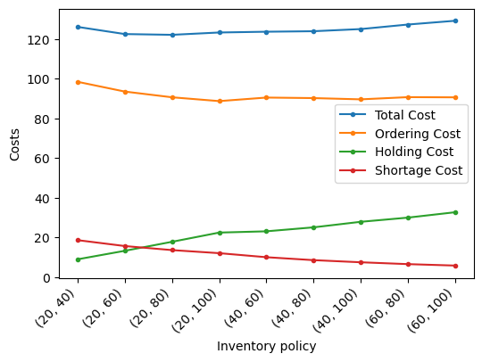

```python
fig, ax = plt.subplots(dpi=100)
ax.plot(df['Total Cost'], label='Total Cost', marker='.')
ax.plot(df['Ordering Cost'], label='Ordering Cost', marker='.')
ax.plot(df['Holding Cost'], label='Holding Cost', marker='.')
ax.plot(df['Shortage Cost'], label='Shortage Cost', marker='.')
plt.xticks(range(len(s)), df['(s,S)'])
plt.xticks(rotation=45,ha='right')
plt.xlabel('Inventory policy')
plt.ylabel('Costs')
plt.legend()
plt.show()
```